# Example 7.2 Mixed (effects) models

Yanming Di

2018-05-17

# Example 7.2

Read pages 237-241 of Kuehl.

Evaluation of two chemistry methods (assay for triglycerides in human serum) on four days. In this example, the four days are considered random effects, but the two methods are considered fixed effects. Why?

## Load the data

```r
## Clean evironment is needed
rm(list=ls());

dd = read.table("../data/EXPL7-2.txt", header=TRUE);
str(dd);
```

```
## 'data.frame':    16 obs. of  3 variables:
##  $ DAY   : int  1 1 1 1 2 2 2 2 3 3 ...
##  $ METHOD: int  1 1 2 2 1 1 2 2 1 1 ...
##  $ TRIGLY: num  142 144 143 147 135 ...
```

```r
head(dd);
```

```
##   DAY METHOD TRIGLY
## 1   1      1  142.3
## 2   1      1  144.0
## 3   1      2  142.9
## 4   1      2  147.4
## 5   2      1  134.9
## 6   2      1  146.3
```

```r
day = factor(dd$DAY);
method = factor(dd$METHOD);
trigly = dd$TRIGLY;
```

## Plot the data

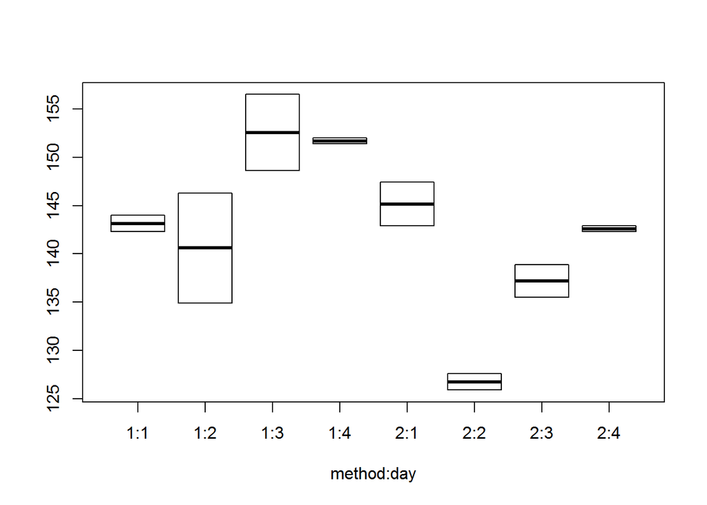

```r
f = method:day;
boxplot(trigly ~ f, xlab="method:day");
```

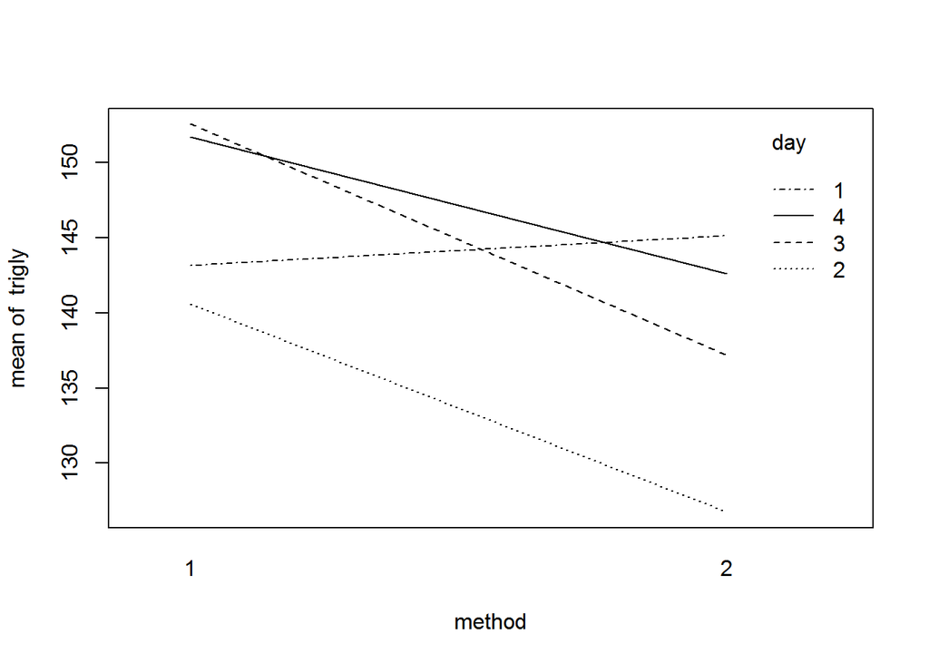

```r
interaction.plot(method, day, trigly);
```

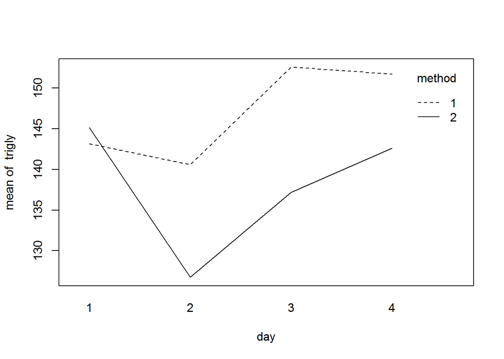

```r
interaction.plot(day, method, trigly);
```

From the plots, we see that there seems to be interaction between machine effect and day effect (but we know that the sample size is small in this example).

## Fit the ANOVA model

The model is:
$$y_{ijk} = \mu + \alpha_i + b_j + (ab)_{ij} + e_{ijk}$$
Note that we use Greek letters for fixed effect terms and Roman/Latin letters for random effect terms.

```r
m = lm(trigly ~ method*day);
anova(m);
```

```
## Analysis of Variance Table
##
## Response: trigly
##            Df Sum Sq Mean Sq F value   Pr(>F)
## method      1 329.42  329.42 22.8488 0.001391 **
## day         3 431.44  143.81  9.9750 0.004442 **
## method:day  3 184.83   61.61  4.2733 0.044602 *
## Residuals   8 115.34   14.42
## ---
## Signif. codes:  0 '***' 0.001 '**' 0.01 '*' 0.05 '.' 0.1 ' ' 1
```

## Expected values of the mean squares

Read page 239 of Kuehl

Suppose we have two factors A (with a levels) and B (with b levels), and A is a fixed effects factor and B is a random effects factor. The expected value of the MSE is given below:

| Source of Variation | d.f. | MS | Expected Mean Squares |
| --- | --- | --- | --- |
| A | a - 1 | MSA | $\sigma^2 +r \sigma^2_{ab} + br\theta^2_{a}$ |
| B | b - 1 | MSB | $\sigma^2 +r \sigma^2_{ab} + ar\sigma^2_{b}$ |
| AB | (a - 1)(b - 1) | MSAB | $\sigma^2 +r \sigma^2_{ab}$ |
| Error | ab(r-1) | MSE | $\sigma^2$ |

The key difference from the random effects model ANOVA is the use of $\theta^2_a = \dfrac{\sum_{i=1}^a \alpha_i^2}{a-1}=\dfrac{\sum_{i=1}^a (\mu_i - \mu)^2}{a-1}$ in the place of $\sigma^2_a$.

```r
a = b = 4;
r = 2;

## Extract mean square values from the ANOVA output
anova.m = anova(m);
ms = anova.m$"Mean Sq";

## Extract df from the ANOVA table
df = anova.m$Df;

## Round the ms values to the 1/100th (I do this for the table dispaly below. This is not necessarily needed in for the practical calculation.)
ms = round(ms, 2)
```

The ANOVA table:

| Source of Variation | d.f. | MS | Expected Mean Squares |
| --- | --- | --- | --- |
| A (method) | 1 | 329.42 | $\sigma^2 +r \sigma^2_{ab} + br\theta^2_{a}$ |
| B (day) | 3 | 143.81 | $\sigma^2 +r \sigma^2_{ab} + ar\sigma^2_{b}$ |
| AB (method $\times$ day) | 3 | 61.61 | $\sigma^2 +r \sigma^2_{ab}$ |
| Error | 8 | 14.42 | $\sigma^2$ |

## Tests for the fixed and random effects

To test the null hypotheses of no method effect (the fixed effect factor) or no day effect (the random effect factor), we use $MSAB$ as the denominator of the corresponding $F$-test—this is same as in the case when both factors are random effects.

### Example 1

To test for no method effect (a fixed effect factor), the null hypothesis is $H_0: \alpha_1 = \alpha_2 = 0$ or equivalently $\mu_1 = \mu_2$. we should use
$$F_0 = MSA/MSAB$$
as the test statistic. Note that here the denominator is still $MSAB$ not $MSE$. To compute the $p$-value, we compare $F_0$ to $F_{a-1, (a-1)(b-1)}$ (we can read the d.f. from the ANOVA table).

```r
## F-statistic and p-value for testing method effect. Remember that in the ANoVA table we fit earlier, row 1 corresponds to method, row 3 corresponds to interaction).
f = ms[1]/ms[3];
p = pf(f, df[1], df[3], lower.tail=FALSE);
```

$F_0 = 329.42/61.61 = 5.3468593$ and p-value is $pf(F_0, 1, 3) =0.1038097$.

### Example 2

```r
## F-statistic and p-value for no day effect. Remember that in the ANoVA table we fit earlier, row 2 corresponds to day, row 3 corresponds to interaction).
f = ms[2]/ms[3];
p = pf(f, df[2], df[3], lower.tail=FALSE);
```

$F_0 = 143.81/61.61 = 2.334199$ and p-value is $pf(F_0, 3, 3) =0.2522249$.

### Example 3

To test no interaction effect, the null hypothesis is $H_0: \sigma_{ab}^2 = 0$, we should
$$F_0 = MSAB/MSE$$
as the statistic and compare it to $F_{(a-1)(b-1), ab(r-1)}$ (we can read the d.f. from the ANOVA table).

```r
## F-statistic and p-value for no interaction effect.
f = ms[3]/ms[4];
p = pf(f, df[3], df[4],lower.tail=FALSE);
```

$F_0 = 61.61/14.42 = 4.2725381$ and p-value is $pf(F_0, 3, 8) =0.044621$.

Given the results of the above three tests, what is our conclusion?

## Inference on contrasts of means

In random effects and mixed efects models, the inference for the contrasts of means is more complicated than in the fixed effects model case.